# task1-Data Preparation And Customer Analytics

#### PROD_NAME

```python
#Examine PROD_NAME
transaction_data.groupby(['PROD_NAME']).count()
```

| PROD_NAME | DATE | STORE_NBR | LYLTY_CARD_NBR | TXN_ID | PROD_NBR | PROD_QTY | TOT_SALES |
| --- | --- | --- | --- | --- | --- | --- | --- |
| Burger Rings 220g | 1564 | 1564 | 1564 | 1564 | 1564 | 1564 | 1564 |
| CCs Nacho Cheese 175g | 1498 | 1498 | 1498 | 1498 | 1498 | 1498 | 1498 |
| CCs Original 175g | 1514 | 1514 | 1514 | 1514 | 1514 | 1514 | 1514 |
| CCs Tasty Cheese 175g | 1539 | 1539 | 1539 | 1539 | 1539 | 1539 | 1539 |
| Cheetos Chs & Bacon Balls 190g | 1479 | 1479 | 1479 | 1479 | 1479 | 1479 | 1479 |
| ... | ... | ... | ... | ... | ... | ... | ... |
| WW Sour Cream &OnionStacked Chips 160g | 1483 | 1483 | 1483 | 1483 | 1483 | 1483 | 1483 |
| WW Supreme Cheese Corn Chips 200g | 1509 | 1509 | 1509 | 1509 | 1509 | 1509 | 1509 |
| Woolworths Cheese Rings 190g | 1516 | 1516 | 1516 | 1516 | 1516 | 1516 | 1516 |
| Woolworths Medium Salsa 300g | 1430 | 1430 | 1430 | 1430 | 1430 | 1430 | 1430 |
| Woolworths Mild Salsa 300g | 1491 | 1491 | 1491 | 1491 | 1491 | 1491 | 1491 |

114 rows × 7 columns

```python
# regular expression
def clean(text):

    text = re.sub(r'[^A-Za-z0-9]+', ' ', text)
    text = re.sub(r'\d\w*', ' ', text)
    return text

transaction_data['PROD_NAME'] =transaction_data['PROD_NAME'].apply(clean)
transaction_data['PROD_NAME']
```

```
0                 Natural Chip Compny SeaSalt
1                            CCs Nacho Cheese
2            Smiths Crinkle Cut Chips Chicken
3            Smiths Chip Thinly S Cream Onion
4         Kettle Tortilla ChpsHny Jlpno Chili
                          ...
264831     Kettle Sweet Chilli And Sour Cream
264832                Tostitos Splash Of Lime
264833                       Doritos Mexicana
264834     Doritos Corn Chip Mexican Jalapeno
264835                Tostitos Splash Of Lime
Name: PROD_NAME, Length: 264836, dtype: object
```

```python
#transaction_data['PROD_NAME'].str.split().str[0]#.value_counts()
text = ''.join(transaction_data['PROD_NAME'])
token_data = word_tokenize(text)
```

```python
#Frequency Distribution
fdist = FreqDist(token_data)
print(fdist)
```

```
<FreqDist with 227 samples and 1116918 outcomes>
```

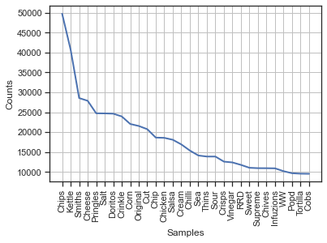

```python
# Frequency Distribution Plot
import matplotlib.pyplot as plt
fdist.plot(30,cumulative=False)
plt.show()
```

```python
#word frequency
counted = Counter(token_data)
word_freq = pd.DataFrame(counted.items(),columns=['word','frequency']).sort_values(by='frequency',ascending=False)
word_freq.head(10)
```

|  | word | frequency |
| --- | --- | --- |
| 10 | Chips | 49770 |
| 16 | Kettle | 40739 |
| 7 | Smiths | 28572 |
| 6 | Cheese | 27890 |
| 66 | Pringles | 24743 |
| 28 | Salt | 24719 |
| 34 | Doritos | 24650 |
| 8 | Crinkle | 23960 |
| 35 | Corn | 22063 |
| 48 | Original | 21560 |

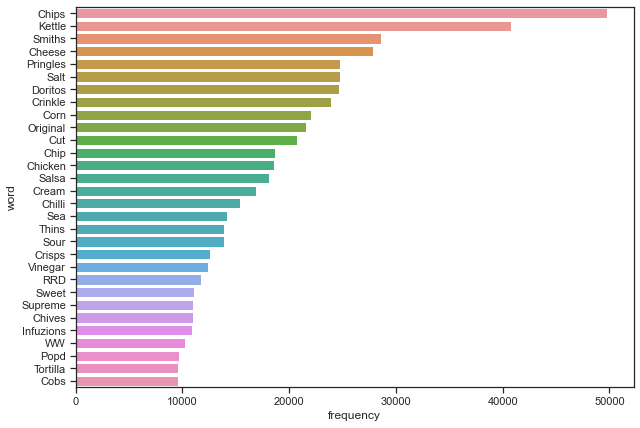

```python
# Frequency Distribution Plot
sns.barplot(x='frequency',y='word',data=word_freq.head(30))
#p.set_xlabel("X-Axis", fontsize = 20)
plt.gcf().set_size_inches(10,7)
```

```python
#Drop salsa
transaction_data=transaction_data[~transaction_data["PROD_NAME"].str.contains(r"[Ss]alsa")]
```

```python
transaction_data.describe()
#product quantity appears to have an outlier 200 max
```

|  | STORE_NBR | LYLTY_CARD_NBR | TXN_ID | PROD_NBR | PROD_QTY | TOT_SALES |
| --- | --- | --- | --- | --- | --- | --- |
| count | 246742.000000 | 2.467420e+05 | 2.467420e+05 | 246742.000000 | 246742.000000 | 246742.000000 |
| mean | 135.051098 | 1.355310e+05 | 1.351311e+05 | 56.351789 | 1.908062 | 7.321322 |
| std | 76.787096 | 8.071528e+04 | 7.814772e+04 | 33.695428 | 0.659831 | 3.077828 |
| min | 1.000000 | 1.000000e+03 | 1.000000e+00 | 1.000000 | 1.000000 | 1.700000 |
| 25% | 70.000000 | 7.001500e+04 | 6.756925e+04 | 26.000000 | 2.000000 | 5.800000 |
| 50% | 130.000000 | 1.303670e+05 | 1.351830e+05 | 53.000000 | 2.000000 | 7.400000 |
| 75% | 203.000000 | 2.030840e+05 | 2.026538e+05 | 87.000000 | 2.000000 | 8.800000 |
| max | 272.000000 | 2.373711e+06 | 2.415841e+06 | 114.000000 | 200.000000 | 650.000000 |

#### Product quantity

```python
# Value counts of PROD_QTY

transaction_data['PROD_QTY'].value_counts()
```

```
2      220070
1       25476
5         415
3         408
4         371
200         2
Name: PROD_QTY, dtype: int64
```

```python
transaction_data[transaction_data["PROD_QTY"] ==200]
```

|  | DATE | STORE_NBR | LYLTY_CARD_NBR | TXN_ID | PROD_NBR | PROD_NAME | PROD_QTY | TOT_SALES |
| --- | --- | --- | --- | --- | --- | --- | --- | --- |
| 69762 | 2018-08-19 | 226 | 226000 | 226201 | 4 | Dorito Corn Chp Supreme | 200 | 650.0 |
| 69763 | 2019-05-20 | 226 | 226000 | 226210 | 4 | Dorito Corn Chp Supreme | 200 | 650.0 |

There are two transactions where 200 packets of chips are bought in one transaction, and both of these transactions were by the same customer.

```python
#Filter out the customer based on the loyalty card number
transaction_data[transaction_data['LYLTY_CARD_NBR'] == 226000]
```

|  | DATE | STORE_NBR | LYLTY_CARD_NBR | TXN_ID | PROD_NBR | PROD_NAME | PROD_QTY | TOT_SALES |
| --- | --- | --- | --- | --- | --- | --- | --- | --- |
| 69762 | 2018-08-19 | 226 | 226000 | 226201 | 4 | Dorito Corn Chp Supreme | 200 | 650.0 |
| 69763 | 2019-05-20 | 226 | 226000 | 226210 | 4 | Dorito Corn Chp Supreme | 200 | 650.0 |

This customer made a total of two transactions and purchased the same 200 items each time. It is possible that this is a bulk purchase from an institution rather than an individual customer, so remove their data

```python
#Removing outliers
transaction_data.drop(transaction_data.index[transaction_data['LYLTY_CARD_NBR'] == 226000], inplace = True)
customer_data.drop(customer_data.index[customer_data['LYLTY_CARD_NBR'] == 226000], inplace = True)
```

## 2 Data Analysis

### 2.1 Transaction data

#### By Date

```python
# Count the number of transactions by date
transaction_data['Counts'] = np.zeros(len(transaction_data))
df_miss = transaction_data.groupby(['DATE']).count().reset_index()
missSales = transaction_data.groupby(['DATE']).sum()['TOT_SALES']
df_miss = df_miss.assign(TOT_SALES = missSales.values)
df_miss= df_miss.loc[:,['DATE','Counts','TOT_SALES']]
df_miss.info()
```

```
<class 'pandas.core.frame.DataFrame'>
RangeIndex: 364 entries, 0 to 363
Data columns (total 3 columns):
 #   Column     Non-Null Count  Dtype
---  ------     --------------  -----
 0   DATE       364 non-null    datetime64[ns]
 1   Counts     364 non-null    int64
 2   TOT_SALES  364 non-null    float64
dtypes: datetime64[ns](1), float64(1), int64(1)
memory usage: 8.7 KB
```

There's only 364 rows, meaning only 364 dates which indicates a missing date. Let's create a sequence of dates from 1 Jul 2018 to 30 Jun 2019 and use this to create a chart of number of transactions over time to find the missing date.

```python
#check the missing date
pd.date_range(start=transaction_data["DATE"].min(), end=transaction_data["DATE"].max()).difference(transaction_data["DATE"])
```

```
DatetimeIndex(['2018-12-25'], dtype='datetime64[ns]', freq=None)
```

```python
#Full year data
df_miss[df_miss['DATE']=='2018-12-24']
df_miss.loc[177]={'DATE':'2018-12-25','Counts':0,'TOT_SALES':0}
df_miss.loc[177]
df_date = df_miss
```

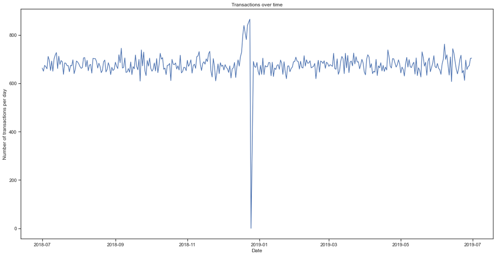

```python
#Plot transactions over time
timeline = df_miss['DATE']
graph = df_miss['Counts']

fig, ax = plt.subplots(figsize = (20, 10))
ax.plot(timeline, graph)

date_form = DateFormatter("%Y-%m")
ax.xaxis.set_major_formatter(date_form)
plt.title('Transactions over time')
plt.xlabel('Date')
plt.ylabel('Number of transactions per day')

plt.show()
```

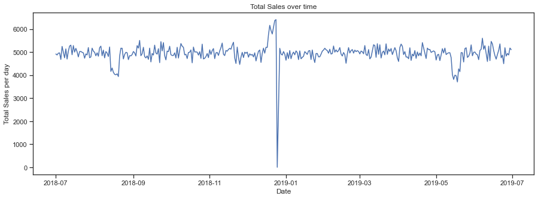

```python
#Plot Sales over time
timeline = df_date['DATE']
graph = df_date ['TOT_SALES']

fig, ax = plt.subplots(figsize = (15, 5))
ax.plot(timeline, graph)

#date_form = DateFormatter("%Y-%m")
#ax.xaxis.set_major_formatter(date_form)
plt.title('Total Sales over time')
plt.xlabel('Date')
plt.ylabel('Total Sales per day')

plt.show()
```

```python
#Sales in December
Dec =  df_date[( df_date.DATE < "2019-01-01") & (df_date.DATE > "2018-11-30")]
```

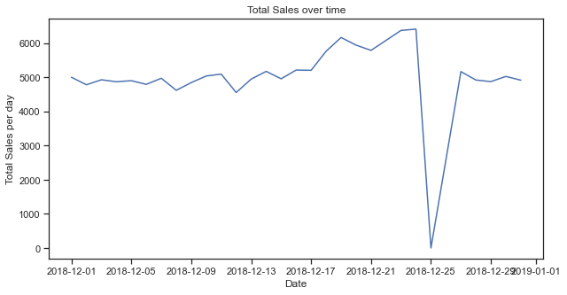

```python
#Plot Sales in DEC.

fig, ax = plt.subplots(figsize = (10, 5))
ax.plot(Dec['DATE'], Dec['TOT_SALES'])

#date_form = DateFormatter("%Y-%m")
#ax.xaxis.set_major_formatter(date_form)
plt.title('Total Sales over time')
plt.xlabel('Date')
plt.ylabel('Total Sales per day')

plt.show()
```

We can see that the increase in sales occurs in the lead-up to Christmas and that there are zero sales on Christmas day itself. This is due to shops being closed on Christmas day.

#### By Pack size

```python
#take the digits in PROD_NAME
transaction_data['SIZE'] = transCopy['PROD_NAME'].str.extract(r"(\d+)")
transaction_data['SIZE'] = pd.to_numeric(transaction_data['SIZE'])
transaction_data['SIZE'].unique()
```

```
array([175, 170, 150, 330, 210, 270, 220, 125, 110, 134, 380, 180, 165,
       135, 250, 200, 160, 190,  90,  70])
```

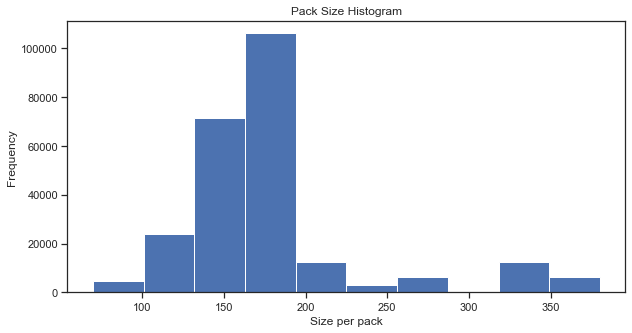

```python
#plot a histogram of Pack size
plt.figure(figsize = (10, 5))
plt.hist(transaction_data['SIZE'])
plt.xlabel('Size per pack')
plt.ylabel('Frequency')
plt.title('Pack Size Histogram')
```

#### By Brands

```python
#Take the first word as brand name
transaction_data['Brands'] = transaction_data['PROD_NAME'].str.split().str[0]
transaction_data.head()
```

|  | DATE | STORE_NBR | LYLTY_CARD_NBR | TXN_ID | PROD_NBR | PROD_NAME | PROD_QTY | TOT_SALES | Counts | SIZE | Brands |
| --- | --- | --- | --- | --- | --- | --- | --- | --- | --- | --- | --- |
| 0 | 2018-10-17 | 1 | 1000 | 1 | 5 | Natural Chip Compny SeaSalt | 2 | 6.0 | 0.0 | 175 | Natural |
| 1 | 2019-05-14 | 1 | 1307 | 348 | 66 | CCs Nacho Cheese | 3 | 6.3 | 0.0 | 175 | CCs |
| 2 | 2019-05-20 | 1 | 1343 | 383 | 61 | Smiths Crinkle Cut Chips Chicken | 2 | 2.9 | 0.0 | 170 | Smiths |
| 3 | 2018-08-17 | 2 | 2373 | 974 | 69 | Smiths Chip Thinly S Cream Onion | 5 | 15.0 | 0.0 | 175 | Smiths |
| 4 | 2018-08-18 | 2 | 2426 | 1038 | 108 | Kettle Tortilla ChpsHny Jlpno Chili | 3 | 13.8 | 0.0 | 150 | Kettle |

```python
#Clean brand names
transaction_data['Brands'].unique()
```

```
array(['Natural', 'CCs', 'Smiths', 'Kettle', 'Grain', 'Doritos',
       'Twisties', 'WW', 'Thins', 'Burger', 'NCC', 'Cheezels', 'Infzns',
       'Red', 'Pringles', 'Dorito', 'Infuzions', 'Smith', 'GrnWves',
       'Tyrrells', 'Cobs', 'French', 'RRD', 'Tostitos', 'Cheetos',
       'Woolworths', 'Snbts', 'Sunbites'], dtype=object)
```

```python
transaction_data.groupby(['Brands']).count()
```

| Brands | DATE | STORE_NBR | LYLTY_CARD_NBR | TXN_ID | PROD_NBR | PROD_NAME | PROD_QTY | TOT_SALES | Counts | SIZE |
| --- | --- | --- | --- | --- | --- | --- | --- | --- | --- | --- |
| Burger | 1564 | 1564 | 1564 | 1564 | 1564 | 1564 | 1564 | 1564 | 1564 | 1564 |
| CCs | 4551 | 4551 | 4551 | 4551 | 4551 | 4551 | 4551 | 4551 | 4551 | 4551 |
| Cheetos | 2927 | 2927 | 2927 | 2927 | 2927 | 2927 | 2927 | 2927 | 2927 | 2927 |
| Cheezels | 4603 | 4603 | 4603 | 4603 | 4603 | 4603 | 4603 | 4603 | 4603 | 4603 |
| Cobs | 9693 | 9693 | 9693 | 9693 | 9693 | 9693 | 9693 | 9693 | 9693 | 9693 |
| Dorito | 3183 | 3183 | 3183 | 3183 | 3183 | 3183 | 3183 | 3183 | 3183 | 3183 |
| Doritos | 22041 | 22041 | 22041 | 22041 | 22041 | 22041 | 22041 | 22041 | 22041 | 22041 |
| French | 1418 | 1418 | 1418 | 1418 | 1418 | 1418 | 1418 | 1418 | 1418 | 1418 |
| Grain | 6272 | 6272 | 6272 | 6272 | 6272 | 6272 | 6272 | 6272 | 6272 | 6272 |
| GrnWves | 1468 | 1468 | 1468 | 1468 | 1468 | 1468 | 1468 | 1468 | 1468 | 1468 |
| Infuzions | 11057 | 11057 | 11057 | 11057 | 11057 | 11057 | 11057 | 11057 | 11057 | 11057 |
| Infzns | 3144 | 3144 | 3144 | 3144 | 3144 | 3144 | 3144 | 3144 | 3144 | 3144 |
| Kettle | 41288 | 41288 | 41288 | 41288 | 41288 | 41288 | 41288 | 41288 | 41288 | 41288 |
| NCC | 1419 | 1419 | 1419 | 1419 | 1419 | 1419 | 1419 | 1419 | 1419 | 1419 |
| Natural | 6050 | 6050 | 6050 | 6050 | 6050 | 6050 | 6050 | 6050 | 6050 | 6050 |
| Pringles | 25102 | 25102 | 25102 | 25102 | 25102 | 25102 | 25102 | 25102 | 25102 | 25102 |
| RRD | 11894 | 11894 | 11894 | 11894 | 11894 | 11894 | 11894 | 11894 | 11894 | 11894 |
| Red | 4427 | 4427 | 4427 | 4427 | 4427 | 4427 | 4427 | 4427 | 4427 | 4427 |
| Smith | 2963 | 2963 | 2963 | 2963 | 2963 | 2963 | 2963 | 2963 | 2963 | 2963 |
| Smiths | 27390 | 27390 | 27390 | 27390 | 27390 | 27390 | 27390 | 27390 | 27390 | 27390 |
| Snbts | 1576 | 1576 | 1576 | 1576 | 1576 | 1576 | 1576 | 1576 | 1576 | 1576 |
| Sunbites | 1432 | 1432 | 1432 | 1432 | 1432 | 1432 | 1432 | 1432 | 1432 | 1432 |
| Thins | 14075 | 14075 | 14075 | 14075 | 14075 | 14075 | 14075 | 14075 | 14075 | 14075 |
| Tostitos | 9471 | 9471 | 9471 | 9471 | 9471 | 9471 | 9471 | 9471 | 9471 | 9471 |
| Twisties | 9454 | 9454 | 9454 | 9454 | 9454 | 9454 | 9454 | 9454 | 9454 | 9454 |
| Tyrrells | 6442 | 6442 | 6442 | 6442 | 6442 | 6442 | 6442 | 6442 | 6442 | 6442 |
| WW | 10320 | 10320 | 10320 | 10320 | 10320 | 10320 | 10320 | 10320 | 10320 | 10320 |
| Woolworths | 1516 | 1516 | 1516 | 1516 | 1516 | 1516 | 1516 | 1516 | 1516 | 1516 |

```python
#define a function to combine same brand
def clean_brand(data):
        x=data['Brands']
        if x=='Natural' or x=='NCC':
            return 'Natural Chip Co.'
        elif x =='Dorito':
            return 'Doritos'
        elif x =='Grain':
            return 'GrnWves'
        elif x =='Infzns':
            return 'Infuzions'
        elif x =='Red':
            return 'RRD'
        elif x =='Smith':
            return 'Smiths'
        elif x =='Snbts':
            return 'Sunbites'
        elif x =='WW':
            return 'Woolworths'
        else:
            return x

transaction_data["Brands"] = transaction_data.apply(lambda data: clean_brand(data), axis=1)
```

```python
#check again
transaction_data["Brands"].unique()
```

```
array(['Natural Chip Co.', 'CCs', 'Smiths', 'Kettle', 'GrnWves',
       'Doritos', 'Twisties', 'Woolworths', 'Thins', 'Burger', 'Cheezels',
       'Infuzions', 'RRD', 'Pringles', 'Tyrrells', 'Cobs', 'French',
       'Tostitos', 'Cheetos', 'Sunbites'], dtype=object)
```

### 2.2 Customer Data

```python
customer_data.head()
```

|  | LYLTY_CARD_NBR | LIFESTAGE | PREMIUM_CUSTOMER |
| --- | --- | --- | --- |
| 0 | 1000 | YOUNG SINGLES/COUPLES | Premium |
| 1 | 1002 | YOUNG SINGLES/COUPLES | Mainstream |
| 2 | 1003 | YOUNG FAMILIES | Budget |
| 3 | 1004 | OLDER SINGLES/COUPLES | Mainstream |
| 4 | 1005 | MIDAGE SINGLES/COUPLES | Mainstream |

### 2.3 Merge Data

```python
##Merge transaction data to customer data
df_merge = pd.merge(transaction_data, customer_data)
```

```python
# Check for missing customer details
df_merge.isnull().sum()
```

```
DATE                0
STORE_NBR           0
LYLTY_CARD_NBR      0
TXN_ID              0
PROD_NBR            0
PROD_NAME           0
PROD_QTY            0
TOT_SALES           0
Counts              0
SIZE                0
Brands              0
LIFESTAGE           0
PREMIUM_CUSTOMER    0
dtype: int64
```

```python
#write out as a csv
```

## 3. Data analysis on customer segments

### 3.1 Total Sales

```python
# total sales by LIFESTAGE and PREMIUM_CUSTOMER
sales = df_merge.groupby(['LIFESTAGE','PREMIUM_CUSTOMER'])[['TOT_SALES']].sum().reset_index()
```

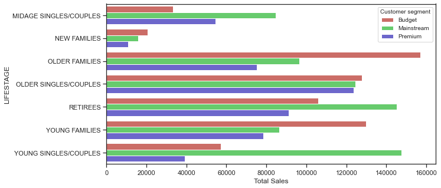

```python
#plot Total sales per lifestage in different customer segment

plt.figure(figsize=(10,5))

ax = sns.barplot( x = "TOT_SALES", y = "LIFESTAGE", hue = "PREMIUM_CUSTOMER", palette = 'hls',data = sales)
ax.set(xlabel='Total Sales')
plt.legend(title = "Customer segment", fontsize = 10, title_fontsize = 10)

plt.show()
```

```python
#Stack bar plot
fig = px.bar(sales,x='LIFESTAGE',y='TOT_SALES',color='PREMIUM_CUSTOMER',text='TOT_SALES',text_auto='.2s',color_discrete_sequence=px.colors.qualitative.Vivid)
#fig.update_traces(texttemplate='%{text:.2s}', textposition='outside')
fig.update_layout(title = {'text': 'Distribution of Sales','x' : 0.5, 'y':0.95},yaxis_title="Total Sales")

fig.update_layout(legend_title_text='Customer Segment')

fig.show()
```

[interactive chart not shown]

### 3.2 Number of customers

```python
##Number of customers by LIFESTAGE and PREMIUM_CUSTOMER
num_cus_ser = df_merge.groupby(["LIFESTAGE", "PREMIUM_CUSTOMER"]).LYLTY_CARD_NBR.nunique().sort_values(ascending=False)
num_cus= pd.DataFrame(num_ser).reset_index()
num_cus.head()
```

|  | LIFESTAGE | PREMIUM_CUSTOMER | LYLTY_CARD_NBR |
| --- | --- | --- | --- |
| 0 | YOUNG SINGLES/COUPLES | Mainstream | 7917 |
| 1 | RETIREES | Mainstream | 6358 |
| 2 | OLDER SINGLES/COUPLES | Mainstream | 4858 |
| 3 | OLDER SINGLES/COUPLES | Budget | 4849 |
| 4 | OLDER SINGLES/COUPLES | Premium | 4682 |

```python
#total number by 'PREMIUM_CUSTOMER'
df_merge.groupby(["PREMIUM_CUSTOMER"]).LYLTY_CARD_NBR.nunique().sort_values(ascending=False)
```

```
PREMIUM_CUSTOMER
Mainstream    28734
Budget        24006
Premium       18547
Name: LYLTY_CARD_NBR, dtype: int64
```

```python
#total number by 'PLIFESTAGE'
df_merge.groupby(["LIFESTAGE"]).LYLTY_CARD_NBR.nunique().sort_values(ascending=False)
```

```
LIFESTAGE
RETIREES                  14555
OLDER SINGLES/COUPLES     14389
YOUNG SINGLES/COUPLES     14044
OLDER FAMILIES             9630
YOUNG FAMILIES             9036
MIDAGE SINGLES/COUPLES     7141
NEW FAMILIES               2492
Name: LYLTY_CARD_NBR, dtype: int64
```

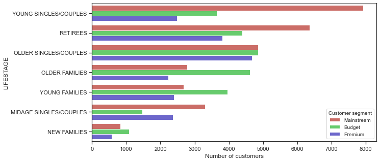

```python
#plot Number of customers per lifestage
plt.figure(figsize=(10,5))

ax1=sns.barplot( x = "LYLTY_CARD_NBR", y = "LIFESTAGE", hue = "PREMIUM_CUSTOMER",palette = 'hls',data = num_cus)
ax1.set(xlabel='Number of customers')
plt.legend(title = "Customer segment", fontsize = 10, title_fontsize = 10)

plt.show()
```

```python
fig = px.bar(num_cus,x='LIFESTAGE',y='LYLTY_CARD_NBR',color='PREMIUM_CUSTOMER',text='LYLTY_CARD_NBR',text_auto='.2s',color_discrete_sequence=px.colors.qualitative.Vivid)
#fig.update_traces(texttemplate='%{text:.2s}', textposition='outside')
fig.update_layout(title = {'text': 'Distribution of Sales','x' : 0.5, 'y':0.95},yaxis_title="Total Sales")

fig.update_layout(legend_title_text='Customer Segment')

fig.show()
```

[interactive chart not shown]

There are more Mainstream - young singles/couples and Mainstream - retirees who buy chips. This contributes to there being more sales to these customer segments but this is not a major driver for the Budget - Older families segment.

Higher sales may also be driven by more units of chips being bought per customer.

### 3.3 Number of units per customer

```python
#Average number of units per customer by LIFESTAGE and PREMIUM_CUSTOMER
avg_units_ser= df_merge.groupby(["LIFESTAGE","PREMIUM_CUSTOMER"]).PROD_QTY.sum()/df_merge.groupby(["LIFESTAGE","PREMIUM_CUSTOMER"]).LYLTY_CARD_NBR.nunique().sort_values(ascending=False)
avg_units = pd.DataFrame(avg_units_ser, columns = {'Average Unit'}).reset_index()
avg_units.head()
```

|  | LIFESTAGE | PREMIUM_CUSTOMER | Average Unit |
| --- | --- | --- | --- |
| 0 | MIDAGE SINGLES/COUPLES | Budget | 6.026459 |
| 1 | MIDAGE SINGLES/COUPLES | Mainstream | 6.432080 |
| 2 | MIDAGE SINGLES/COUPLES | Premium | 6.078514 |
| 3 | NEW FAMILIES | Budget | 4.821527 |
| 4 | NEW FAMILIES | Mainstream | 4.891566 |

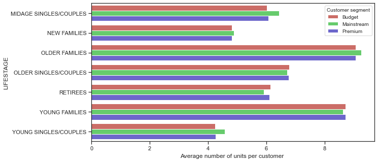

```python
plt.figure(figsize=(10,5))

ax1=sns.barplot( x = "Average Unit", y = "LIFESTAGE", hue = "PREMIUM_CUSTOMER",palette = 'hls',data = avg_units)
ax1.set(xlabel='Average number of units per customer ')
plt.legend(title = "Customer segment", fontsize = 10, title_fontsize = 10)

plt.show()
```

### 3.4 Price per quantity per unique customer

```python
#Average price per unit by LIFESTAGE and PREMIUM_CUSTOMER
avg_price = df_merge.groupby(["PREMIUM_CUSTOMER","LIFESTAGE"]).TOT_SALES.sum()/num_cus_ser/avg_units_ser
avg_price = pd.DataFrame(avg_price, columns = {'Average price'}).reset_index()
avg_price.head()
```

|  | PREMIUM_CUSTOMER | LIFESTAGE | Average price |
| --- | --- | --- | --- |
| 0 | Budget | MIDAGE SINGLES/COUPLES | 3.753878 |
| 1 | Budget | NEW FAMILIES | 3.931969 |
| 2 | Budget | OLDER FAMILIES | 3.747969 |
| 3 | Budget | OLDER SINGLES/COUPLES | 3.887529 |
| 4 | Budget | RETIREES | 3.932731 |

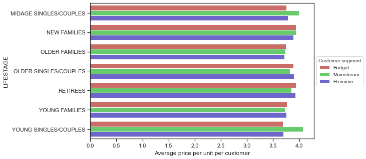

```python
plt.figure(figsize=(8,5))

ax1=sns.barplot( x = "Average price", y = "LIFESTAGE", hue = "PREMIUM_CUSTOMER",palette = 'hls',data = avg_price)
ax1.set(xlabel='Average price per unit per customer')
plt.legend(title = "Customer segment", fontsize = 10, title_fontsize = 10,loc='center left', bbox_to_anchor=(1, 0.5))

plt.show()
```

Mainstream midage and young singles and couples are more willing to pay more perpacket of chips compared to their budget and premium counterparts. This may be dueto premium shoppers being more likely to buy healthy snacks and when they buychips, this is mainly for entertainment purposes rather than their own consumption.This is also supported by there being fewer premium midage and young singles andcouples buying chips compared to their mainstream counterparts.

#### T-test

```python
#Perform an independent t-test between mainstream vs premium and budget midage and young singles and couples

mainstream = df_merge["PREMIUM_CUSTOMER"] == "Mainstream"
young_midage = (df_merge["LIFESTAGE"] == "MIDAGE SINGLES/COUPLES") | (df_merge["LIFESTAGE"] == "YOUNG SINGLES/COUPLES")

non_mainstream = (df_merge["PREMIUM_CUSTOMER"] == "Budget") | (df_merge["PREMIUM_CUSTOMER"] == "Premium")

a = df_merge[young_midage & mainstream]["TOT_SALES"]
b = df_merge[young_midage & non_mainstream]["TOT_SALES"]
res= ttest_ind(a.values, b.values, equal_var=False)
print(res)
```

```
Ttest_indResult(statistic=33.06748508665193, pvalue=1.834645908183037e-237)
```

## 4. Affinity analysis

We might want to target customer segments that contribute the most to sales to retain them or further increase sales. I would target Mainstream - young singles/couples to see if they tend to buy a particular brand of chips.

### Apriori and association rules

```python
Mainstream_basket = df_merge.loc[(df_merge['LIFESTAGE'] == 'YOUNG SINGLES/COUPLES') & (df_merge['PREMIUM_CUSTOMER'] == 'Mainstream'), :]
Mainstream_basket  = Mainstream_basket.iloc[:,[2,6,10]]
nonTarget = df_merge.loc[(df_merge['LIFESTAGE'] != 'YOUNG SINGLES/COUPLES' ) & (df_merge['PREMIUM_CUSTOMER'] != 'Mainstream'), :]
nonTarget= nonTarget.iloc[:,[2,6,10]]
Mainstream_basket.head()
```

|  | LYLTY_CARD_NBR | PROD_QTY | Brands |
| --- | --- | --- | --- |
| 221345 | 1020 | 1 | Smiths |
| 221346 | 1020 | 1 | Smiths |
| 221347 | 1020 | 1 | GrnWves |
| 221348 | 1163 | 1 | Kettle |
| 221349 | 1163 | 1 | Natural Chip Co. |

```python
Mainstream_basket = Mainstream_basket.groupby(['LYLTY_CARD_NBR','Brands']).PROD_QTY.count().unstack().fillna(0)
```

```python
def encode_units(x):
    if x <= 0:
        return 0
    if x >= 1:
        return 1

Mainstream_basket = Mainstream_basket.applymap(encode_units)
```

```python
frequent_itemsets = apriori(Mainstream_basket, min_support=0.001, use_colnames=True, max_len=5)
frequent_itemsets
```

|  | support | itemsets |
| --- | --- | --- |
| 0 | 0.007579 | (Burger) |
| 1 | 0.026652 | (CCs) |
| 2 | 0.020336 | (Cheetos) |
| 3 | 0.042440 | (Cheezels) |
| 4 | 0.103827 | (Cobs) |
| ... | ... | ... |
| 1078 | 0.001137 | (Natural Chip Co., RRD, Kettle, Woolworths, Sm... |
| 1079 | 0.001010 | (RRD, Kettle, Pringles, Thins, Smiths) |
| 1080 | 0.001137 | (RRD, Kettle, Woolworths, Pringles, Smiths) |
| 1081 | 0.001010 | (Kettle, Pringles, Thins, Smiths, Tostitos) |
| 1082 | 0.001010 | (Kettle, Woolworths, Pringles, Thins, Smiths) |

1083 rows × 2 columns

```python
rules = association_rules(frequent_itemsets, metric="lift")
rules.head()
```

|  | antecedents | consequents | antecedent support | consequent support | support | confidence | lift | leverage | conviction |
| --- | --- | --- | --- | --- | --- | --- | --- | --- | --- |
| 0 | (Burger) | (Cheetos) | 0.007579 | 0.020336 | 0.001010 | 0.133333 | 6.556522 | 0.000856 | 1.130382 |
| 1 | (Cheetos) | (Burger) | 0.020336 | 0.007579 | 0.001010 | 0.049689 | 6.556522 | 0.000856 | 1.044313 |
| 2 | (Burger) | (Doritos) | 0.007579 | 0.260326 | 0.002779 | 0.366667 | 1.408491 | 0.000806 | 1.167907 |
| 3 | (Doritos) | (Burger) | 0.260326 | 0.007579 | 0.002779 | 0.010674 | 1.408491 | 0.000806 | 1.003129 |
| 4 | (Burger) | (Infuzions) | 0.007579 | 0.143110 | 0.001389 | 0.183333 | 1.281068 | 0.000305 | 1.049253 |

### 4.2. Affinity to Brand

```python
#target data
young_mainstream = df_merge[(df_merge['LIFESTAGE']=='YOUNG SINGLES/COUPLES') & (df_merge['PREMIUM_CUSTOMER']=='Mainstream')]
#by brand
quantity_bybrand = young_mainstream.groupby(['Brands'])[['PROD_QTY']].sum().reset_index()
quantity_bybrand.PROD_QTY = quantity_bybrand.PROD_QTY / young_mainstream.PROD_QTY.sum()
quantity_bybrand = quantity_bybrand.rename(columns={"PROD_QTY": "Targeted_Segment"})
```

```python
#other segments data
other_segments = pd.concat([alldat, young_mainstream]).drop_duplicates(keep=False) # remove young_mainsream
#by brand
quantity_bybrand_other = other_segments.groupby(['Brands'])[['PROD_QTY']].sum().reset_index()
quantity_bybrand_other.PROD_QTY = quantity_bybrand_other.PROD_QTY / other_segments.PROD_QTY.sum()
quantity_bybrand_other = quantity_bybrand_other.rename(columns={"PROD_QTY": "Other_Segment"})
```

```python
quantity_bybrand = quantity_bybrand.merge(quantity_bybrand_other, on ='Brands')
quantity_bybrand['Affinitytobrand'] = quantity_bybrand['Targeted_Segment'] / quantity_bybrand['Other_Segment']
quantity_bybrand = quantity_bybrand.sort_values('Affinitytobrand')
quantity_bybrand.head()
```

|  | Brands | Targeted_Segment | Other_Segment | Affinitytobrand |
| --- | --- | --- | --- | --- |
| 0 | Burger | 0.002926 | 0.006101 | 0.479621 |
| 19 | Woolworths | 0.024099 | 0.046027 | 0.523592 |
| 14 | Sunbites | 0.006349 | 0.011746 | 0.540553 |
| 1 | CCs | 0.011180 | 0.017878 | 0.625340 |
| 12 | RRD | 0.043810 | 0.064417 | 0.680090 |

```python
#plot the Affinity
fig = go.Figure(data=[
    go.Bar(name='Target Segment', x=quantity_bybrand['Brands'], y=quantity_bybrand['Targeted_Segment']),
    go.Bar(name='Other Segement', x=quantity_bybrand['Brands'], y=quantity_bybrand['Other_Segment'])
])

fig.update_layout(
    title= "",
    xaxis_title="Brands",
    yaxis_title="Affinity",
    legend_title="Legend Title",
)

fig.update_layout(barmode='group',width=800,height=500)
fig.update_layout(xaxis={'categoryorder':'total ascending'})
fig.update_xaxes(tickangle=30)
fig.show()
```

[interactive chart not shown]

Mainstream young singles/couples are more likely to purchase Kettle, Doritos, and Smiths chips compared to other brands. For other segements, the preferred three brands are the same as the target group, except that the Smiths brand turns out to be the second most in demand.

### 4.2. Affinity to Size

```python
# Target : mainstream - young
bysize = young_mainstream.groupby(['SIZE'])[['PROD_QTY']].sum().reset_index()
bysize.PROD_QTY = bysize.PROD_QTY / young_mainstream.PROD_QTY.sum()

bysize = bysize.rename(columns={"PROD_QTY": "Targeted_Segment"})
#Non-target
bysize_other = other_segments.groupby(['SIZE'])[['PROD_QTY']].sum().reset_index()
bysize_other.PROD_QTY = bysize_other.PROD_QTY / other_segments.PROD_QTY.sum()
bysize_other = bysize_other.rename(columns={"PROD_QTY": "Other_Segment"})

bysize = bysize.merge(bysize_other, on='SIZE')
bysize['Affinitytosize'] = bysize['Targeted_Segment'] / bysize['Other_Segment']
bysize = bysize.sort_values('Affinitytosize')
bysize.head()
```

|  | SIZE | Targeted_Segment | Other_Segment | Affinitytosize |
| --- | --- | --- | --- | --- |
| 15 | 220 | 0.002926 | 0.006101 | 0.479621 |
| 0 | 70 | 0.003037 | 0.005881 | 0.516353 |
| 13 | 200 | 0.008972 | 0.017355 | 0.516957 |
| 3 | 125 | 0.003009 | 0.005631 | 0.534368 |
| 1 | 90 | 0.006349 | 0.011746 | 0.540553 |

```python
#plot the Affinity by size
bysize['SIZE'] = bysize['SIZE'].apply(str)
fig = go.Figure(data=[
    go.Bar(name='Target Segment', x=bysize['SIZE'], y=bysize['Targeted_Segment']),
    go.Bar(name='Other Segement', x=bysize['SIZE'], y=bysize['Other_Segment'])
])

fig.update_layout(barmode='group',width=800,height=500)
fig.update_layout(xaxis={'categoryorder':'total ascending'})
fig.update_xaxes(tickangle=30)
fig.show()
```

[interactive chart not shown]

Mainstream young singles/couples are more likely to purchase 175g chips compared to other size.The second preference is 150g. The same goes for non-target groups.